# Statistical Learning Final Project

STA3241.01 – April 23, 2021

Amelia Wood

# Introduction

The purpose of this project was to use the data from the eBayAuctions dataset to build a model that will classify auctions as either competitive or non-competitive. I explored multiple different models throughout this project including, Classification Trees, Logistic Regression, Support Vector Machines, Lasso and Ridge Regression, and Ordinary Least Squares. The comparisons for the models can be seen throughout this project. The full code for this project can be found [here](https://github.com/amelia-wood/SL_final_project.git).

# Dataset

I first obtained my dataset from the reisanar/datasets GitHub Repo. I then changed the Duration variable to be a factor. The Data Dictionary for this dataset can be seen below.

## Data Dictionary

| Field Name | Description | Data Type |
| --- | --- | --- |
| Category | Category of the auctioned item | character |
| currency | Currency | character |
| sellerRating | A rating by eBay, as a function of the number of “good” and “bad” transactions the seller had on eBay | double |
| Duration | Number of days the auction lasted (set by seller at auction start) | factor |
| endDay | Day of week that the auction closed | character |
| ClosePrice | Price item sold at (converted into USD) | double |
| OpenPrice | Initial price set by the seller (converted into USD) | double |
| Competitive? | Whether the auction had a single bid (0) or more (1) | double |

# Modeling

## Preprocessing

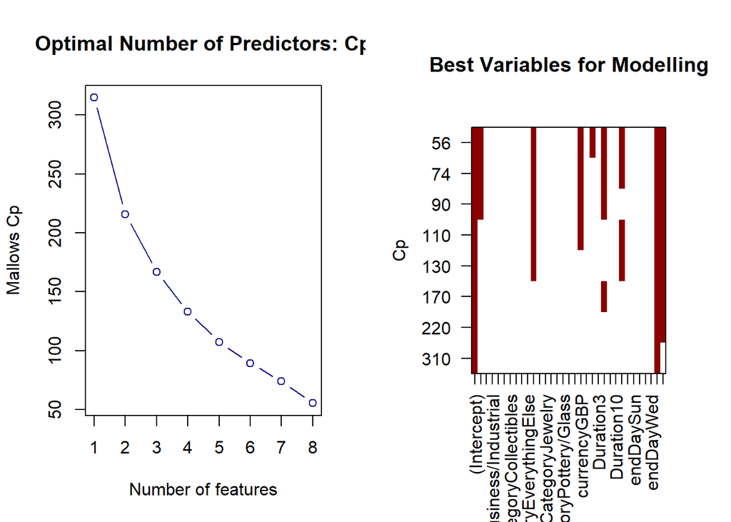

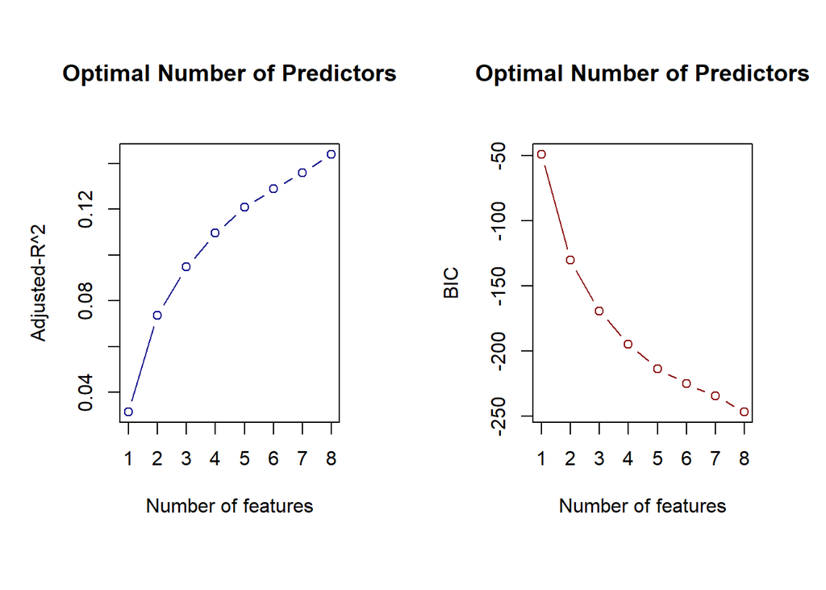

## Classification Tree

The first model I chose to explore was a Classification tree.

```r
dt_auctions
```

```
## CART
##
## 1184 samples
##    7 predictor
##
## No pre-processing
## Resampling: Cross-Validated (10 fold)
## Summary of sample sizes: 1066, 1065, 1065, 1065, 1065, 1066, ...
## Resampling results across tuning parameters:
##
##   cp           RMSE       Rsquared   MAE
##   0.008930268  0.3223454  0.5825982  0.1928151
##   0.008966725  0.3214262  0.5843569  0.1927938
##   0.020170367  0.3449317  0.5192595  0.2265141
##   0.023579309  0.3566591  0.4893795  0.2436482
##   0.026919450  0.3618091  0.4759766  0.2532375
##   0.029612398  0.3666606  0.4624798  0.2604077
##   0.031877424  0.3742772  0.4415532  0.2730636
##   0.055940514  0.3999467  0.3644835  0.3122399
##   0.060538075  0.4133555  0.3191933  0.3349173
##   0.150833661  0.4586203  0.2551828  0.4142434
##
## RMSE was used to select the optimal model using the smallest value.
## The final value used for the model was cp = 0.008966725.
```

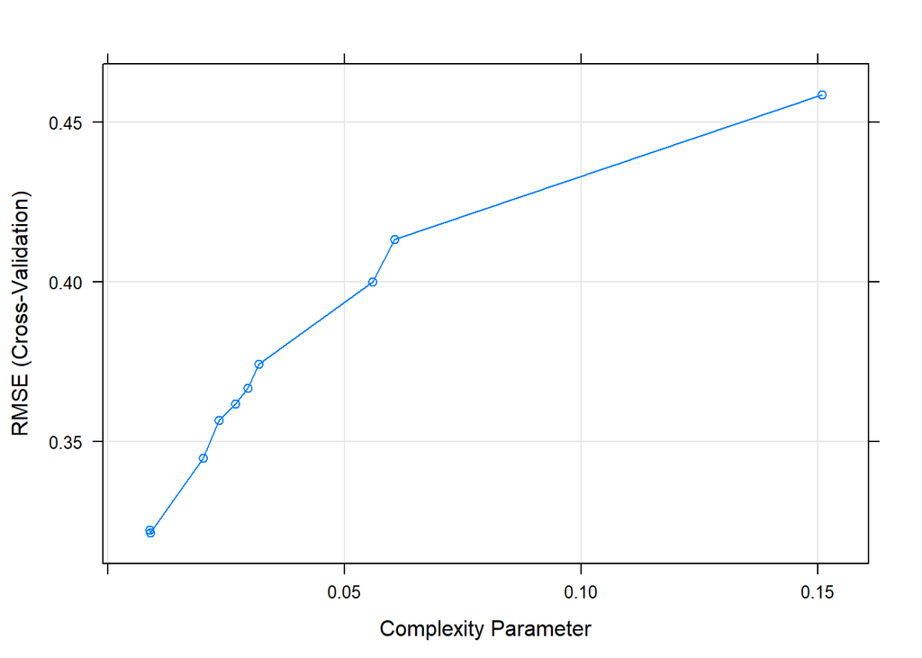

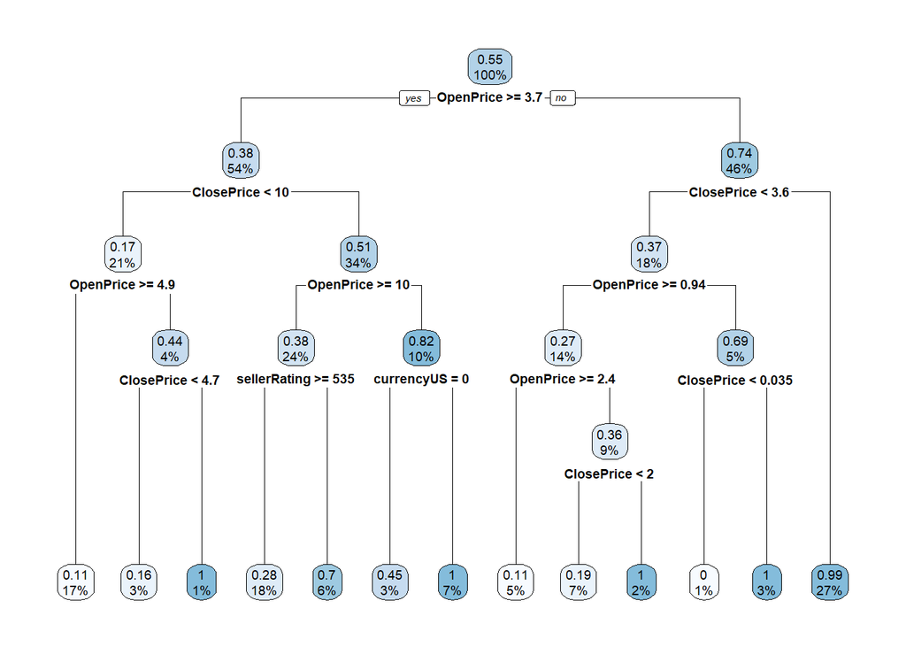

## Logistic Regression

```r
# basic logistic regression model
auctions_lr <- glm(Competitive. ~ Category + sellerRating + Duration + endDay + OpenPrice, family = "binomial", data = auctions)
summary(auctions_lr)
```

```
##
## Call:
## glm(formula = Competitive. ~ Category + sellerRating + Duration +
##     endDay + OpenPrice, family = "binomial", data = auctions)
##
## Deviance Residuals:
##    Min      1Q  Median      3Q     Max
## -2.346  -1.109   0.720   1.034   2.716
##
## Coefficients:
##                                Estimate Std. Error z value Pr(>|z|)
## (Intercept)                   4.208e-01  4.771e-01   0.882 0.377835
## CategoryAutomotive           -7.100e-01  2.502e-01  -2.838 0.004541 **
## CategoryBooks                -2.907e-01  3.233e-01  -0.899 0.368623
## CategoryBusiness/Industrial   6.178e-01  5.348e-01   1.155 0.247999
## CategoryClothing/Accessories -3.308e-01  2.550e-01  -1.297 0.194534
## CategoryCoins/Stamps         -1.234e+00  4.133e-01  -2.986 0.002828 **
## CategoryCollectibles          1.698e-01  2.141e-01   0.793 0.427897
## CategoryComputer              3.501e-01  4.034e-01   0.868 0.385459
## CategoryElectronics           1.097e+00  3.841e-01   2.857 0.004280 **
## CategoryEverythingElse       -1.669e+00  6.015e-01  -2.774 0.005532 **
## CategoryHealth/Beauty        -1.902e+00  3.721e-01  -5.111 3.21e-07 ***
## CategoryHome/Garden           3.475e-01  2.721e-01   1.277 0.201668
## CategoryJewelry              -6.875e-01  2.911e-01  -2.362 0.018181 *
## CategoryMusic/Movie/Game     -2.057e-01  2.000e-01  -1.028 0.303756
## CategoryPhotography           1.391e+00  7.953e-01   1.749 0.080248 .
## CategoryPottery/Glass        -4.979e-01  5.167e-01  -0.964 0.335282
## CategorySportingGoods         8.531e-01  2.850e-01   2.994 0.002756 **
## CategoryToys/Hobbies          1.270e-01  2.178e-01   0.583 0.559695
## sellerRating                 -5.081e-05  1.028e-05  -4.944 7.67e-07 ***
## Duration3                    -4.457e-02  4.799e-01  -0.093 0.926003
## Duration5                     4.266e-01  4.773e-01   0.894 0.371395
## Duration7                    -1.859e-01  4.626e-01  -0.402 0.687771
## Duration10                   -2.389e-01  4.779e-01  -0.500 0.617109
## endDayMon                     6.235e-01  1.806e-01   3.453 0.000555 ***
## endDaySat                    -3.385e-01  1.803e-01  -1.878 0.060411 .
## endDaySun                    -1.353e-01  1.780e-01  -0.760 0.447143
## endDayThu                     4.136e-01  2.088e-01   1.981 0.047579 *
## endDayTue                     1.061e-01  2.131e-01   0.498 0.618509
## endDayWed                    -1.629e-01  2.951e-01  -0.552 0.580787
## OpenPrice                    -4.900e-03  2.075e-03  -2.362 0.018171 *
## ---
## Signif. codes:  0 '***' 0.001 '**' 0.01 '*' 0.05 '.' 0.1 ' ' 1
##
## (Dispersion parameter for binomial family taken to be 1)
##
##     Null deviance: 2720.8  on 1971  degrees of freedom
## Residual deviance: 2462.1  on 1942  degrees of freedom
## AIC: 2522.1
##
## Number of Fisher Scoring iterations: 4
```

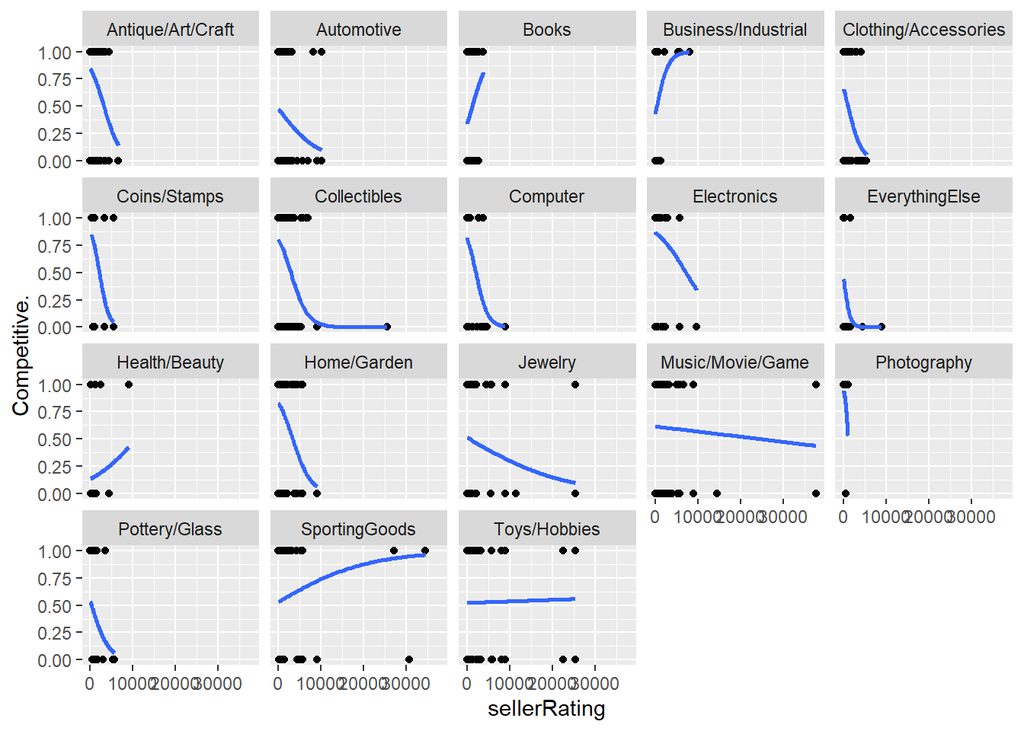

## SVM

In this section, I used two different support vector methods to predict whether an auction is competitive or not.

I first created a Support Vector Machine with a Linear Kernel, seen below.

```r
svm_model_1
```

```
## Support Vector Machines with Linear Kernel
##
## 1382 samples
##    7 predictor
##    2 classes: 'No', 'Yes'
##
## Pre-processing: centered (32), scaled (32)
## Resampling: Cross-Validated (10 fold)
## Summary of sample sizes: 1244, 1244, 1243, 1245, 1243, 1244, ...
## Resampling results across tuning parameters:
##
##   C     ROC        Sens       Spec
##   0.01  0.7125375  0.5621032  0.7295135
##   0.05  0.7511477  0.6015625  0.7374595
##   0.10  0.7683783  0.6298859  0.7294595
##   0.25  0.7928305  0.6772073  0.7134955
##   0.50  0.8162377  0.7228175  0.7228829
##   0.75  0.8260175  0.7480407  0.7095856
##   1.00  0.8315880  0.7715774  0.7189910
##   1.25  0.8356841  0.7842262  0.7216577
##   1.50  0.8386295  0.7967014  0.7162703
##   1.75  0.8407363  0.7998512  0.7189550
##   2.00  0.8424402  0.8061012  0.7216036
##   5.00  0.8537919  0.8329861  0.7269009
##
## ROC was used to select the optimal model using the largest value.
## The final value used for the model was C = 5.
```

Next, I created a Support Vector Machine with a Radial Kernel, seen below.

```r
svm_rad_1
```

```
## Support Vector Machines with Radial Basis Function Kernel
##
## 1382 samples
##    7 predictor
##    2 classes: 'No', 'Yes'
##
## Pre-processing: centered (32), scaled (32)
## Resampling: Cross-Validated (10 fold)
## Summary of sample sizes: 1243, 1244, 1243, 1245, 1243, 1244, ...
## Resampling results across tuning parameters:
##
##   C     sigma  ROC        Sens       Spec
##   0.10  0.001  0.6845487  0.6849702  0.5581802
##   0.10  0.010  0.6911797  0.6754712  0.5795676
##   0.10  0.100  0.7042140  0.5636161  0.7176577
##   0.25  0.001  0.6844853  0.6865575  0.5675135
##   0.25  0.010  0.7019591  0.5387649  0.7027387
##   0.25  0.100  0.7148537  0.5416419  0.7376757
##   0.50  0.001  0.6845062  0.6881200  0.5608468
##   0.50  0.010  0.7108226  0.5402282  0.7201081
##   0.50  0.100  0.7263148  0.5604663  0.7322883
##   0.75  0.001  0.6853196  0.6582093  0.5821982
##   0.75  0.010  0.7202502  0.5323165  0.7347928
##   0.75  0.100  0.7338643  0.5620040  0.7376216
##   1.00  0.001  0.6894208  0.5843750  0.6518378
##   1.00  0.010  0.7300365  0.5339038  0.7388649
##   1.00  0.100  0.7404341  0.5588790  0.7349730
##   1.25  0.001  0.6927531  0.5576637  0.6959640
##   1.25  0.010  0.7389978  0.5479911  0.7295315
##   1.25  0.100  0.7434832  0.5713542  0.7296396
##   1.50  0.001  0.6949989  0.5387649  0.7053514
##   1.50  0.010  0.7468101  0.5479415  0.7295315
##   1.50  0.100  0.7441918  0.5650794  0.7229369
##
## ROC was used to select the optimal model using the largest value.
## The final values used for the model were sigma = 0.01 and C = 1.5.
```

This plot shows the AUC-ROC for the Linear SVM and Radial SVM. The Linear SVM has an AUC-ROC of 0.85 while the Radial SVM has an AUC-ROC of 0.73, making the Linear SVM the better option in this case.

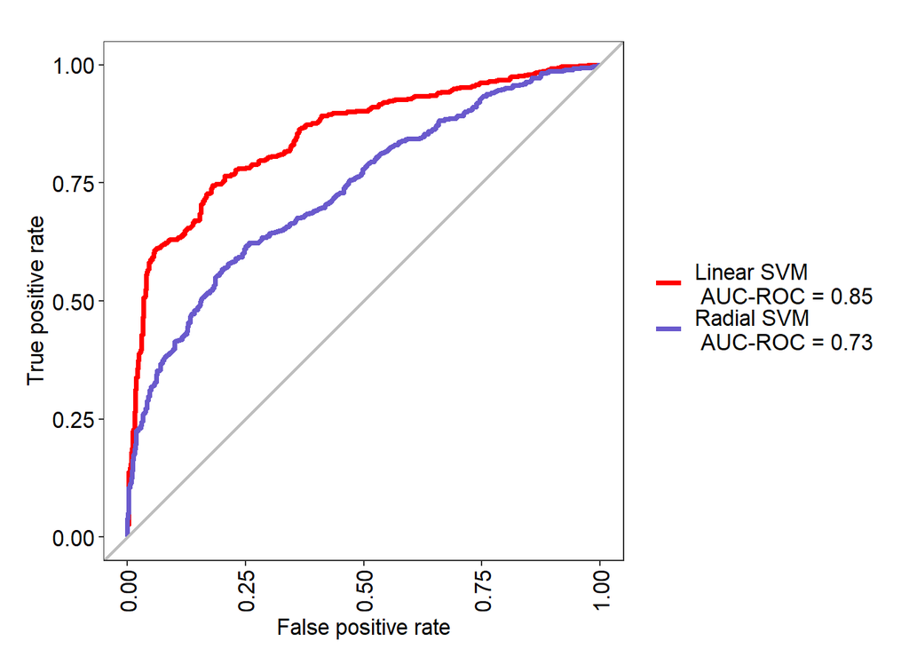

## Other Techniques

### Ridge Regression

```r
ridge_model <- train(ClosePrice ~ ., data = train_set,
               method = "glmnet",
               trControl = train_control,
               metric =  "Rsquared",
               tuneGrid = expand.grid(alpha = 0, lambda = grid))
```

Coefficients for the Ridge Regression model.

```r
# Model coefficients
coef(ridge_model$finalModel, ridge_model$bestTune$lambda)
```

```
## 33 x 1 sparse Matrix of class "dgCMatrix"
##                                          1
## (Intercept)                   2.326731e+01
## CategoryAutomotive            2.260652e+01
## CategoryBooks                 3.690479e-01
## CategoryBusiness/Industrial   8.958804e+00
## CategoryClothing/Accessories  1.525749e+01
## CategoryCoins/Stamps          1.265757e+00
## CategoryCollectibles          7.743970e+00
## CategoryComputer              4.873945e+01
## CategoryElectronics           3.994310e+01
## CategoryEverythingElse        2.235131e+00
## CategoryHealth/Beauty        -1.129855e+00
## CategoryHome/Garden           5.720554e+00
## CategoryJewelry              -2.244657e+00
## CategoryMusic/Movie/Game     -1.233671e+01
## CategoryPhotography           1.460109e+02
## CategoryPottery/Glass        -4.829986e+00
## CategorySportingGoods         6.202590e+01
## CategoryToys/Hobbies         -2.049712e+00
## currencyGBP                   1.493649e+00
## currencyUS                   -2.707013e+00
## sellerRating                 -2.635467e-04
## Duration3                    -2.548593e+01
## Duration5                    -1.502163e+01
## Duration7                    -2.553148e+01
## Duration10                   -2.432197e+01
## endDayMon                     9.812380e-02
## endDaySat                     5.637563e+00
## endDaySun                     9.464260e-01
## endDayThu                    -1.029013e+01
## endDayTue                    -7.287346e+00
## endDayWed                    -1.178630e+01
## OpenPrice                     1.004378e+00
## Competitive.1                 2.962809e+01
```

RMSE and Rsquare for the Ridge Regression model.

```r
# Model prediction performance
data.frame(
  RMSE = RMSE(predictions_ridge, test_set$ClosePrice),
  Rsquare = R2(predictions_ridge, test_set$ClosePrice)
)
```

```
##       RMSE  Rsquare
## 1 89.75394 0.204665
```

### LASSO

```r
lasso_model <- train(ClosePrice ~ ., data = train_set,
               method = "glmnet",
               trControl = train_control,
               #metric =  "Rsquared",
               #tuneGrid = expand.grid(alpha = 1, lambda = ridge_model$finalModel$lambdaOpt)
               tuneGrid = expand.grid(alpha = 1, lambda = grid)
               )
```

Coefficients for the Lasso model.

```r
# Model coefficients
coef(lasso_model$finalModel, lasso_model$bestTune$lambda)
```

```
## 33 x 1 sparse Matrix of class "dgCMatrix"
##                                       1
## (Intercept)                    5.498576
## CategoryAutomotive             7.610369
## CategoryBooks                  .
## CategoryBusiness/Industrial    .
## CategoryClothing/Accessories   .
## CategoryCoins/Stamps           .
## CategoryCollectibles           .
## CategoryComputer              27.298281
## CategoryElectronics           22.124552
## CategoryEverythingElse         .
## CategoryHealth/Beauty          .
## CategoryHome/Garden            .
## CategoryJewelry                .
## CategoryMusic/Movie/Game     -10.132502
## CategoryPhotography          114.823356
## CategoryPottery/Glass          .
## CategorySportingGoods         48.970209
## CategoryToys/Hobbies           .
## currencyGBP                    .
## currencyUS                     .
## sellerRating                   .
## Duration3                      .
## Duration5                      .
## Duration7                     -4.570083
## Duration10                     .
## endDayMon                      .
## endDaySat                      .
## endDaySun                      .
## endDayThu                      .
## endDayTue                      .
## endDayWed                      .
## OpenPrice                      1.018239
## Competitive.1                 26.891894
```

RMSE and Rsquare for Lasso.

```r
# Model prediction performance
data.frame(
  RMSE = RMSE(predictions_lasso, test_set$ClosePrice),
  Rsquare = R2(predictions_lasso, test_set$ClosePrice)
)
```

```
##       RMSE   Rsquare
## 1 90.40864 0.1990356
```

### Ordinary Least-Squares

```r
linear_model <- train(ClosePrice ~ ., data = train_set,
                      method = 'lm',
                      metric =  "Rsquared"
              )
```

Coefficients for the Ordinary Least-Squares model.

```r
coef(linear_model$finalModel)
```

```
##                    (Intercept)             CategoryAutomotive
##                   8.104477e+01                   2.594893e+01
##                  CategoryBooks  `CategoryBusiness/Industrial`
##                   3.436090e+00                   1.310368e+01
## `CategoryClothing/Accessories`         `CategoryCoins/Stamps`
##                   2.091015e+01                   5.600232e+00
##           CategoryCollectibles               CategoryComputer
##                   1.304166e+01                   5.090984e+01
##            CategoryElectronics         CategoryEverythingElse
##                   4.574340e+01                   8.007813e+00
##        `CategoryHealth/Beauty`          `CategoryHome/Garden`
##                   2.668146e+00                   9.778862e+00
##                CategoryJewelry     `CategoryMusic/Movie/Game`
##                   5.473317e-02                  -8.420986e+00
##            CategoryPhotography        `CategoryPottery/Glass`
##                   1.578113e+02                  -2.737505e+00
##          CategorySportingGoods         `CategoryToys/Hobbies`
##                   6.827558e+01                   1.652275e-01
##                    currencyGBP                     currencyUS
##                   5.288192e+00                  -4.468539e+00
##                   sellerRating                      Duration3
##                  -2.986316e-04                  -9.169762e+01
##                      Duration5                      Duration7
##                  -8.259363e+01                  -9.114121e+01
##                     Duration10                      endDayMon
##                  -9.206395e+01                   5.722642e+00
##                      endDaySat                      endDaySun
##                   1.009006e+01                   5.573836e+00
##                      endDayThu                      endDayTue
##                  -1.188706e+01                  -3.072691e+00
##                      endDayWed                      OpenPrice
##                  -8.270564e+00                   1.062083e+00
##                  Competitive.1
##                   3.124971e+01
```

### Comparing Ridge, Lasso, and Ordinary Least-Squares

After creating the models for Ridge, Lasso, and Ordinary Least Squares, I wanted to compare them to one another to see which was the best model that minimizes the prediction error.

```r
my_models <- list(ridge = ridge_model, lasso = lasso_model)
resamples(my_models) %>%
  summary( metric = "RMSE")
```

```
##
## Call:
## summary.resamples(object = ., metric = "RMSE")
##
## Models: ridge, lasso
## Number of resamples: 10
##
## RMSE
##           Min.  1st Qu.   Median     Mean  3rd Qu.     Max. NA's
## ridge 35.45570 42.28626 51.49635 64.77893 94.37415 100.3480    0
## lasso 32.71429 47.38892 53.58685 65.54090 92.99451 110.4893    0
```

Here are the predictions for each model:

```r
predictions_lasso <- predict(lasso_model, test_set)
predictions_ridge <- predict(ridge_model, test_set)
predictions_linear <- predict(linear_model, test_set)

data.frame(
  Ridge_R2 = R2(predictions_ridge, test_set$ClosePrice),
  Lasso_R2 = R2(predictions_lasso, test_set$ClosePrice),
  Linear_R2 = R2(predictions_linear, test_set$ClosePrice)
)
```

```
##   Ridge_R2  Lasso_R2 Linear_R2
## 1 0.204665 0.1990356 0.2092954
```

Below, I compared the coefficients of each model to one another.

```r
data.frame(
  ridge = as.data.frame.matrix(coef(ridge_model$finalModel, ridge_model$finalModel$lambdaOpt)),
  lasso = as.data.frame.matrix(coef(lasso_model$finalModel, lasso_model$finalModel$lambdaOpt)),
  linear = (linear_model$finalModel$coefficients)
) %>%
  rename(ridge = X1, lasso = X1.1)
```

```
##                                      ridge      lasso        linear
## (Intercept)                   2.326731e+01   5.498576  8.104477e+01
## CategoryAutomotive            2.260652e+01   7.610369  2.594893e+01
## CategoryBooks                 3.690479e-01   0.000000  3.436090e+00
## CategoryBusiness/Industrial   8.958804e+00   0.000000  1.310368e+01
## CategoryClothing/Accessories  1.525749e+01   0.000000  2.091015e+01
## CategoryCoins/Stamps          1.265757e+00   0.000000  5.600232e+00
## CategoryCollectibles          7.743970e+00   0.000000  1.304166e+01
## CategoryComputer              4.873945e+01  27.298281  5.090984e+01
## CategoryElectronics           3.994310e+01  22.124552  4.574340e+01
## CategoryEverythingElse        2.235131e+00   0.000000  8.007813e+00
## CategoryHealth/Beauty        -1.129855e+00   0.000000  2.668146e+00
## CategoryHome/Garden           5.720554e+00   0.000000  9.778862e+00
## CategoryJewelry              -2.244657e+00   0.000000  5.473317e-02
## CategoryMusic/Movie/Game     -1.233671e+01 -10.132502 -8.420986e+00
## CategoryPhotography           1.460109e+02 114.823356  1.578113e+02
## CategoryPottery/Glass        -4.829986e+00   0.000000 -2.737505e+00
## CategorySportingGoods         6.202590e+01  48.970209  6.827558e+01
## CategoryToys/Hobbies         -2.049712e+00   0.000000  1.652275e-01
## currencyGBP                   1.493649e+00   0.000000  5.288192e+00
## currencyUS                   -2.707013e+00   0.000000 -4.468539e+00
## sellerRating                 -2.635467e-04   0.000000 -2.986316e-04
## Duration3                    -2.548593e+01   0.000000 -9.169762e+01
## Duration5                    -1.502163e+01   0.000000 -8.259363e+01
## Duration7                    -2.553148e+01  -4.570083 -9.114121e+01
## Duration10                   -2.432197e+01   0.000000 -9.206395e+01
## endDayMon                     9.812380e-02   0.000000  5.722642e+00
## endDaySat                     5.637563e+00   0.000000  1.009006e+01
## endDaySun                     9.464260e-01   0.000000  5.573836e+00
## endDayThu                    -1.029013e+01   0.000000 -1.188706e+01
## endDayTue                    -7.287346e+00   0.000000 -3.072691e+00
## endDayWed                    -1.178630e+01   0.000000 -8.270564e+00
## OpenPrice                     1.004378e+00   1.018239  1.062083e+00
## Competitive.1                 2.962809e+01  26.891894  3.124971e+01
```

This interactive graph shows the coefficient path for the Ridge Regression model.

[interactive chart not shown]

This interactive graph shows the coefficient path for the Lasso model.

[interactive chart not shown]